# Data Science עם R - הערה לגבי התאמת יתר overfitting

עדי שריד / adi@sarid-ins.co.il

ראינו ביחידות הקודמות אלגוריתמים שונים. במהלך היחידות הזכרנו מושג הנקרא over-fitting או “התאמת יתר”. כמו כן, הקפדנו בכל החישובים לחלק את הנתונים ל-train ול-test.

בחלק זה נדגים את החשיבות של החלוקה ל-train/test ואת הזהירות המתבקשת כדי להימנע מהתאמת יתר.

התאמת יתר קוראת כאשר מספר המשתנים המסבירים, $p$ גדול מאוד בהשוואה לגודל המדגם $n$.

במילים אחרות, ככל שמספר המשתנים גדל, אז אלגוריתמים שונים מצליחים למצוא מודל שמתאים לנתונים הנצפים בצורה טובה, כביכול מתאר קשר סטטיסטי, אך בפועל הסיבה לכך היא שהאלגוריתם מתאר קשר מקרי-אקראי בעזרת דרגות החופש הרבות שקיימות בפרמטרים.

הדגמה:

- ניקח משתנה תלוי $y$ אקראי לגמרי, ונגריל 100 תצפיות ממנו.
- ניקח 95 פרמטרים $x_1,\ldots,x_{95}$ ונגריל גם מהם 100 תצפיות.
- נבנה מודל (זה לא כל כך משנה איזה, בהדגמה שלנו נשתמש ברגרסיה לינארית).
- ננתח את טיב המודל.
- נחזור על התהליך עם חלוקה ל-train/test.

```r
library(tidyverse)

xvars <- data.frame(matrix(runif(100*95), ncol=95))
overfitting <- tibble(y = runif(100)) %>%
  bind_cols(xvars)

glimpse(overfitting)
```

```
## Observations: 100
## Variables: 96
## $ y   <dbl> 0.39023284, 0.20517646, 0.75111523, 0.84549248, 0.02164303...
## $ X1  <dbl> 0.76191320, 0.59288521, 0.03873932, 0.50658883, 0.07497703...
## $ X2  <dbl> 0.1028826, 0.3647874, 0.2959608, 0.1677630, 0.9551151, 0.4...
## $ X3  <dbl> 0.89013317, 0.09039212, 0.04964639, 0.26259919, 0.86803517...
## $ X4  <dbl> 0.85749243, 0.74810222, 0.07776638, 0.27447017, 0.74164379...
## $ X5  <dbl> 0.9690234, 0.4167513, 0.4563751, 0.7409035, 0.6006922, 0.7...
## $ X6  <dbl> 0.38566486, 0.98264819, 0.94339723, 0.26027243, 0.79292338...
## $ X7  <dbl> 0.00431324, 0.13276755, 0.79449564, 0.37770243, 0.30847842...
## $ X8  <dbl> 0.33158164, 0.08539250, 0.78147906, 0.49760850, 0.26978851...
## $ X9  <dbl> 0.26734530, 0.88357032, 0.26157588, 0.16193688, 0.16161094...
## $ X10 <dbl> 0.09154578, 0.52149782, 0.61861975, 0.23700153, 0.13142343...
## $ X11 <dbl> 0.14684458, 0.88338621, 0.24756255, 0.79427209, 0.24546818...
## $ X12 <dbl> 0.52992472, 0.61666513, 0.06222660, 0.87023565, 0.09296786...
```

[output cut: 83 more lines]

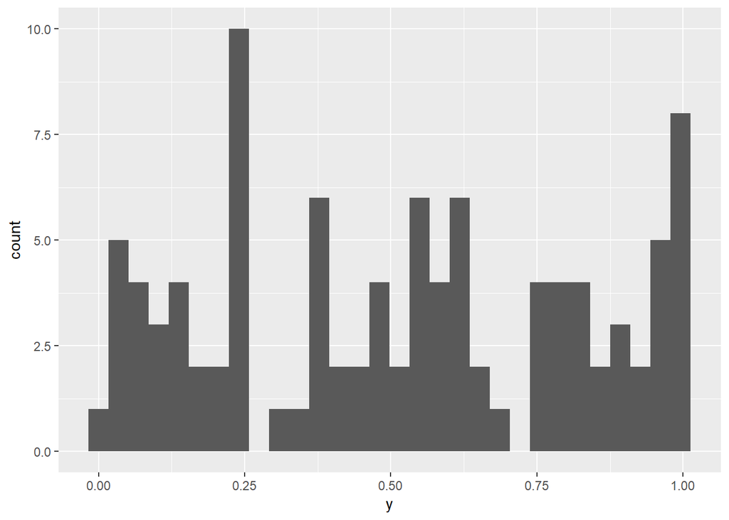

```r
ggplot(overfitting, aes(y)) + geom_histogram()
```

```r
# these are just uniformly distributed numbers, should have no kind of relationship between variables
# here's a model with just a few X's, and no overfit. The model is insignificant.
# the only significant coefficient beta is the intercept (which is roughly equal to the average of y)
lm_no_overfit <- lm(data = overfitting,
                    formula = y ~ X1 + X2 + X3)
summary(lm_no_overfit)
```

```
##
## Call:
## lm(formula = y ~ X1 + X2 + X3, data = overfitting)
##
## Residuals:
##      Min       1Q   Median       3Q      Max
## -0.54152 -0.26483  0.00454  0.26985  0.50720
##
## Coefficients:
##             Estimate Std. Error t value Pr(>|t|)
## (Intercept)   0.5437     0.1041   5.222 1.03e-06 ***
## X1            0.0181     0.1089   0.166    0.868
## X2           -0.1384     0.1114  -1.242    0.217
## X3            0.0870     0.1105   0.787    0.433
## ---
## Signif. codes:  0 '***' 0.001 '**' 0.01 '*' 0.05 '.' 0.1 ' ' 1
##
## Residual standard error: 0.3144 on 96 degrees of freedom
## Multiple R-squared:  0.02143,    Adjusted R-squared:  -0.009148
## F-statistic: 0.7009 on 3 and 96 DF,  p-value: 0.5538
```

```r
# now, see what happens when we add all the 95 features
# mostly, look at the R^2. It's almost 1!
lm_overfit <- lm(data = overfitting,
                 formula = y ~ .)
summary(lm_overfit)
```

```
##
## Call:
## lm(formula = y ~ ., data = overfitting)
##
## Residuals:
##          1          2          3          4          5          6
##  0.0032701 -0.0008632 -0.0457535  0.0145777 -0.0449298  0.0019910
##          7          8          9         10         11         12
## -0.0192260 -0.0153801 -0.0044815  0.0176140  0.0477651  0.0309042
##         13         14         15         16         17         18
## -0.0224583 -0.0175963 -0.0355521  0.0204842 -0.0047382 -0.0168791
##         19         20         21         22         23         24
## -0.0138328 -0.0596875  0.0244194 -0.0296639  0.0357686 -0.0343872
##         25         26         27         28         29         30
##  0.0146473  0.0023392 -0.0483566  0.0496992  0.0629053 -0.0645790
##         31         32         33         34         35         36
## -0.0740118 -0.0643705  0.0198115  0.0216395  0.0773719 -0.0037795
##         37         38         39         40         41         42
## -0.0249681 -0.0162229  0.0657734  0.0193029  0.0046737 -0.0291188
##         43         44         45         46         47         48
##  0.0133577 -0.0068104 -0.0015330  0.0454994  0.0640893 -0.0146306
##         49         50         51         52         53         54
## -0.0515162 -0.0138342  0.0415444 -0.0210369 -0.0539127  0.0463846
##         55         56         57         58         59         60
##  0.0340687  0.0595818 -0.0099070  0.0045365 -0.0169552  0.0115292
##         61         62         63         64         65         66
##  0.0241420 -0.0352004 -0.0272604 -0.0076991 -0.0093505  0.0517225
##         67         68         69         70         71         72
##  0.0033904 -0.0194254 -0.0785038 -0.0057595  0.0082245  0.0603069
##         73         74         75         76         77         78
## -0.0879376 -0.0116958  0.0140021 -0.0202869 -0.0006964  0.0081839
##         79         80         81         82         83         84
## -0.0067624  0.0031466 -0.0757704  0.0209841  0.0007716  0.0078240
##         85         86         87         88         89         90
## -0.0442470 -0.0114168 -0.0214946  0.1039605  0.0430692 -0.0878841
##         91         92         93         94         95         96
## -0.0096534 -0.0462199  0.0693292  0.0871607 -0.0118998  0.0457893
##         97         98         99        100
## -0.0370228  0.0223321  0.0877887  0.0194822
##
```

[output cut: 89 more lines]

```
## X87          0.087188   0.333045   0.262   0.8064
## X88          0.236214   0.249167   0.948   0.3968
## X89         -0.253126   0.287138  -0.882   0.4278
## X90         -0.110791   0.265864  -0.417   0.6983
## X91         -0.236875   0.295243  -0.802   0.4673
## X92          0.220703   0.356240   0.620   0.5691
## X93         -0.753682   0.262510  -2.871   0.0454 *
## X94          0.074610   0.291802   0.256   0.8108
## X95          0.117496   0.202164   0.581   0.5923
## ---
## Signif. codes:  0 '***' 0.001 '**' 0.01 '*' 0.05 '.' 0.1 ' ' 1
##
## Residual standard error: 0.1983 on 4 degrees of freedom
## Multiple R-squared:  0.9838, Adjusted R-squared:  0.5984
## F-statistic: 2.553 on 95 and 4 DF,  p-value: 0.1859
```

```r
# now, see the errors of each model
overfitting <- overfitting %>%
  mutate(res_no_overfit = y - predict(lm_no_overfit, newdata = overfitting),
         res_overfit = y - predict(lm_overfit, newdata = overfitting))

overfitting %>%
  summarize(mean(abs(res_no_overfit)),
            mean(abs(res_overfit)))
```

```
## # A tibble: 1 x 2
##   `mean(abs(res_no_overfit))` `mean(abs(res_overfit))`
##                         <dbl>                    <dbl>
## 1                       0.265                   0.0307
```

```r
# 80%+ reduction in mean absolute residual error!
```

עד כה עבדנו בלי חלוקה ל-train/test, ועל פניו זה נראה כאילו המודל שהתאמנו עם הרבה משתנים, הוא ממש טוב. כפי שניחשתם, זה בלוף…

כעת נחזור על התרגיל, רק שהפעם נמדוד את עצמנו ב-test set.

```r
overfitting <- overfitting %>%
  mutate(is_train = runif(nrow(overfitting)) < 0.8)

lm_overfit_train <- lm(data = overfitting %>% filter(is_train),
                       formula = y ~ .)

overfitting <- overfitting %>%
  mutate(res_overfit_train = y - predict(lm_overfit_train, newdata = overfitting))
overfitting %>%
  filter(!is_train) %>%
  summarize(mean(abs(res_no_overfit)),
            mean(abs(res_overfit)),
            mean(abs(res_overfit_train)))
```

```
## # A tibble: 1 x 3
##   `mean(abs(res_no_overfi~ `mean(abs(res_overfit~ `mean(abs(res_overfit_tr~
##                      <dbl>                  <dbl>                     <dbl>
## 1                    0.277                 0.0335                      1.24
```

```r
# Now the "true face" of the model is discovered. See how high the error rate of the test set is!
# Beware of overfitting models. Always use train/test. Watch out for n and p.
```

## לסיכום

- היזהרו מהתאמת יתר.
- תמיד חלקו את הנתונים ל-train/test.
- תפעילו שיקול דעת תוך התחשבות במספר הפמטרים $p$ לעומת גודל המדגם $n$.

שימו לב שאין “כלל ברזל” בנוגע ליחס בין $n$ לבין $p$, אבל שיעור הטעות של ה-test set הוא הרבה פעמים בעל משמעות עסקית, ודרך משמעות זו ניתן להבין האם המודל עוזר או שלא. כמו כן, ניתן להשוות בין מודל בסיסי-נומינלי, לבין המודל שלכם, ולראות מה מידת התרומה של המודל המורכב יותר.